# DataViz Makeover 1

An assignment on data visualisation critique, and ways to improve and rework.

Dylan Wong https://www.linkedin.com/in/dylan-wong/  
01-26-2021

# Overview

This assignment sets to critically assess the data visualisation of Resident Labour by Age published by the Ministry of Manpower in the *Labour Force in Singapore Advance Release 2019* report.

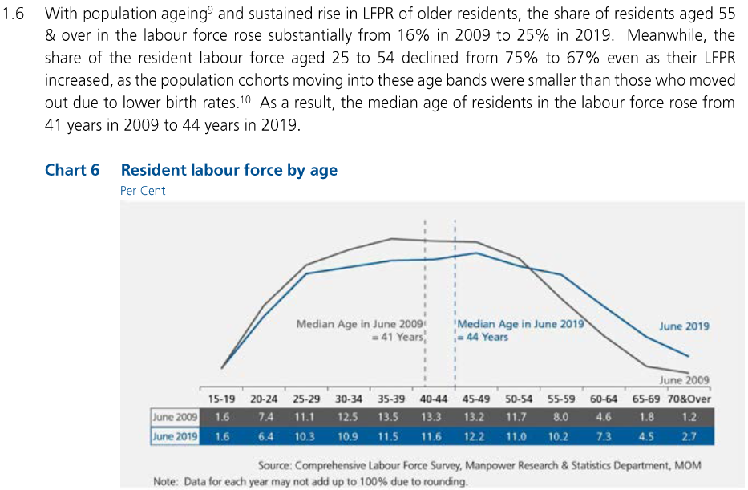

Adopted from Labour Force in Singapore Advance Release 2019

# A. Critiques

## Clarity

1. The details highlighted in the write-up is not visualised clearly on the chart. While readers could manually calculate the changes of the sum of the multiple age groups across the 2 years, it would be more intuitive if the charts could convey the message intended by the author.
2. The data table below the chart is useful in showing the difference in the percentages of resident labour force between the 2 years. However, just by looking at the line chart itself, readers would not be able to figure out the percentage value as the y-axis is not present.
3. The data points could not be identified easily, especially so for age 55-59 in 2009 and both age 55-59 and 60-64 in 2019 where the lines appears to be linear.
4. At the first glance of the chart and without reading into the details, readers may mistake the chart as depicting changes over time as that it the typical use of line chart.
5. While “Per Cent” is the spelling in UK English, which is also the English system adopted by Singapore, “Percent” is more commonly used in Singapore educational system. Local readers may second guess on whether the term is referring to “per cent” in monetary term.
6. The title of the chart is clear but provides little details of what the chart is about.

## Aesthetics

1. The colours of the data table matches that of the line chart. It helps readers to easily identify the corresponding line when they are referring to the data table.
2. The 2 colours choice is not ideal and it does not allow readers to immediately notice the differences especially when the report was published in low resolution.
3. There is no grid lines to guide the data points to the x-axis, requiring reader to put in more effort to mentally trace the data point to the corresponding age group.
4. Line graphs are typically used to display data or information that changes over time continously or when trend needs to be observed. Since age groups are categorical, it would be more appropriate to for bar graphs or pie charts to be use especially since the data shown is in percentage.

# B. Proposed alternative Data Visualisation

| No. | Critiques (Clarity) | Suggestions |
| --- | --- | --- |
| 1 | The details highlighted in the write-up is not visualised clearly on the chart. While readers could manually calculate the changes of the sum of the multiple age groups across the 2 years, it would be… | Text could be added below the title to emphasise on the message the author is trying to convey |
| 2 | The data table below the chart is useful in showing the difference in the percentages of resident labour force between the 2 years. However, just by looking at the line chart itself, readers would not… | Retain the data table. Add the y-axis with grid lines to enable readers the option to read off the chart without having to refer to the table. |
| 3 | The data points could not be identified easily, especially so for age 55-59 in 2009 and both age 55-59 and 60-64 in 2019 where the lines appears to be linear. | Either have data points with size larger than the thickness of the lines, or change the chart type to a bar chart to better depict the percentage level |
| 4 | At the first glance of the chart and without reading into the details, readers may mistake the chart as depicting changes over time as that it the typical use of line chart. | Since age group is of categorical type, the use of bar charts will be more ideal. |
| 5 | While “Per Cent” is the spelling in UK English, which is also the English system adopted by Singapore, “Percent” is more commonly used in Singapore educational system. Local readers may second guess o… | Change the unit title from “Per Cent” to “Percent”, and include the symbol “%” for make it more identifiable. |
| 6 | The title of the chart is clear but provides little details of what the chart is about. | Improve the title by changing it to “Comparison of the resident labour force participaton between 2009 and 2019 by age”. |

| No. | Critiques (Aesthetics) | Suggestions |
| --- | --- | --- |
| 1 | The colours of the data table matches that of the line chart. It helps readers to easily identify the corresponding line when they are referring to the data table. | Retain the use of matching colours of chart and data table. |
| 2 | The 2 colours are not very distinct. To make the matter worse, the background is of grey colour - same color but of different tone as 2009 line. It is a poor choice of colours especially when the repo… | Improve the colour contrast by changing the colour from dark grey-blue to orange-blue, and use white background. |
| 3 | There is no grid lines to guide the data points to the x-axis, requiring reader to put in more effort to mentally trace the data point to the corresponding age group. | Since it is proposed that the chart type be changed to bar chart, there is no longer a need for vertical grid line or reference line. However, if line chart is to be use, grid lines should be added. |
| 4 | Line graphs are typically used to display data or information that changes over time continously or when trend needs to be observed. Since age groups are categorical, it would be more appropriate to f… | As aforementioned, the chart type proposed is bar chart. |

# C. Proposed Data Visualisation

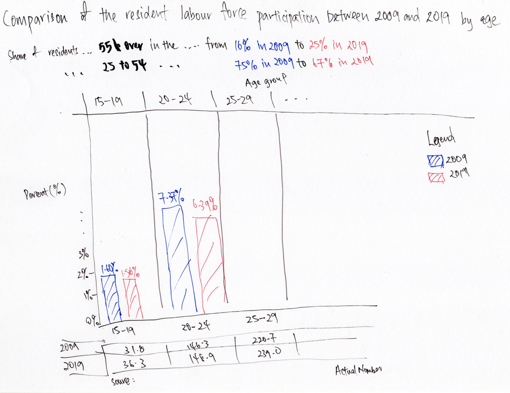

# D. Step-by-step description of the Data Visualisation preparation

## 1. Preparation of data source

- Download the Excel data *(7) Resident Labour Force Aged Fifteen Years and Over by Age and Sex, 2009 - 2019 (June)* from https://stats.mom.gov.sg/iMAS_Tables1/LabourForce/LabourForce_2019/mrsd_2019LabourForce_T7.xlsx

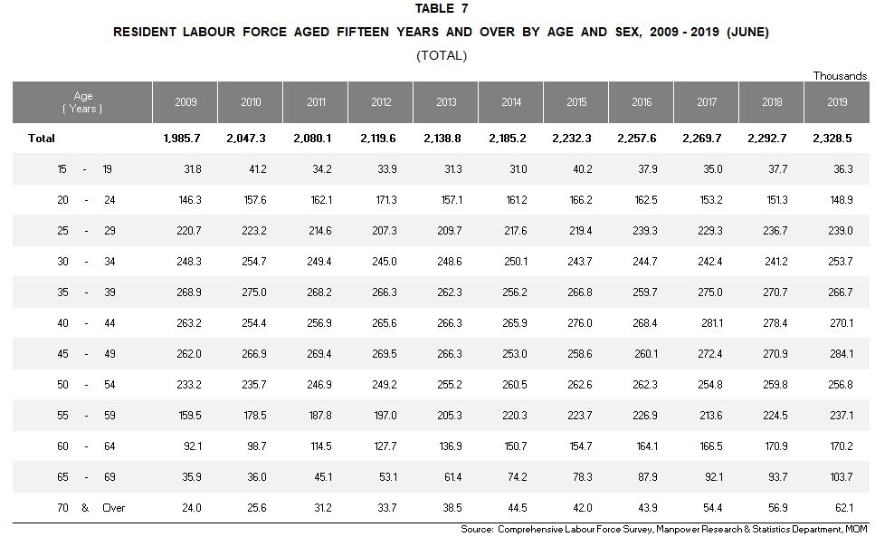

## 2. Reformat the data in sheet T7_T using Microsoft Excel

- Select the entire sheet and Clear Formats
- Delete Rows 1 to 4, 6, and 19
- Cut cell B1 and past in cell D1
- Delete Columns A to C and F to X
- Insert new columns at Column D and compute the percentage of total for each age group
- Rename “Age (Years)” as “Age Group”, “2009” as “2009 Number”, “2019” as “2019 Number”, and the computed percentages as “2009” and “2019” respectively
- Find and replace the spacing in the data under Column A, and rename “70 & Over” as “>=70”
- Finally, remove the other sheets and save the file as “Cleaned Data.xlsx”

[figure not shown]

## 3. Importing to Tableau

- Open up Tableau and import Cleaned Data.xlsx

[figure not shown]

## 4. Visualising using bar chart

- On a new worksheet, drag and drop *Age Group* to Columns and *2009* and *2019* to Rows

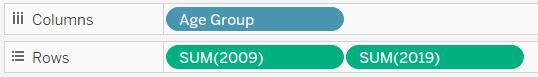

- Select **side-by-side bars** under **Show Me**

[figure not shown]

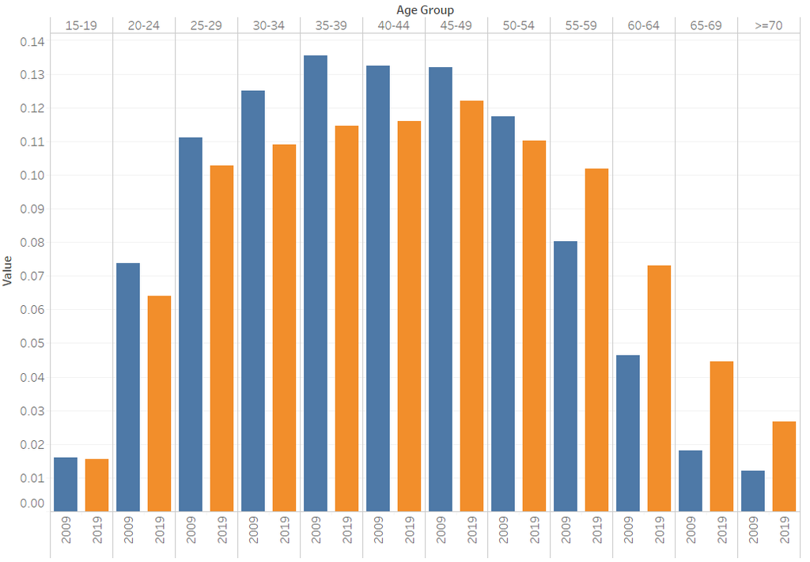

- Turn on **Show Mark Labels** to display the percentage value above each bar
- Change the number format of both measures *2009* and *2019* to percentage by right-clicking the measures, select Default Properties > Number Format > Percentage

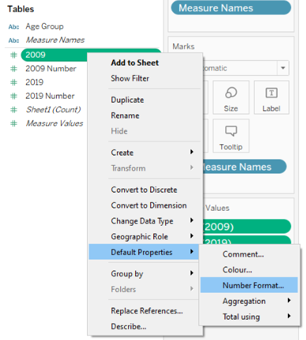

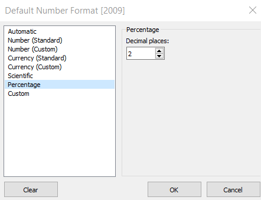

- Similarly, format the y-axis value to percentage by right-clicking the y-axis, **Format > Scale > Numbers > Percentage**

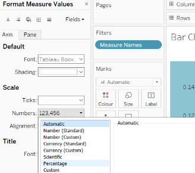

- Since the measure names are displayed as legend at the* side, there is no need to have “2009” and “2019” repeated across the a-xis. This could be removed by selecting the drop down at Measure Names and unchecking **Show Header**

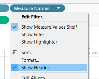

- As a final touch up on the bar chart, right-click on any part of the y-axis and select **Edit Axis**. Under Title, change the text from “Value” to “Percent (%)”

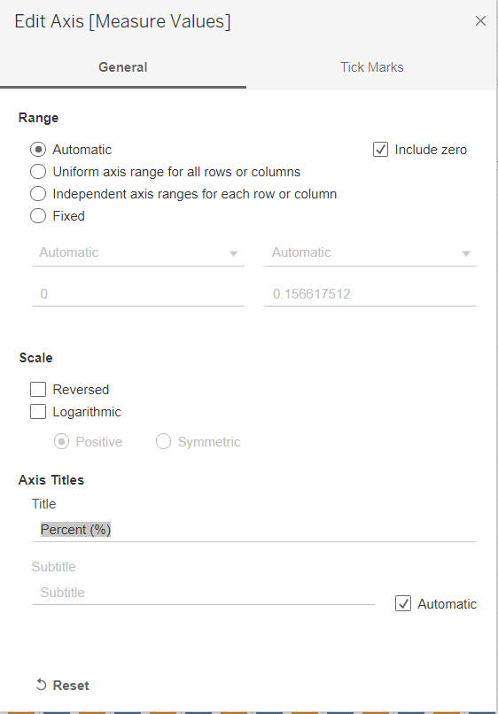

## 5. Creating data table

- On a new worksheet, drag and drop *2009 Number* and *2019 Number* to Rows, and *Age Group* to Columns. Next, select **text tables** under **Show Me**

[figure not shown]

- Swap *Measure Names* from Columns to Rows, and *Age Group* from Rows to Columns.
- Amend the header names by right-clicking on *2009 Number* and *2019 Number*, and change them to *2009* and *2019* respectively by selecting **Edit Alias**.
- select **Analytics** on the side panel and click on **Totals** to compute the grand total of resident labour force in each year

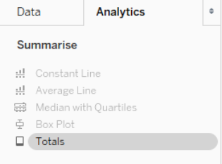

- Final step here is to hide away the title by right-clicking on the title and selecting **Hide Title**

[figure not shown]

## 6. Creating Dashboard

- On a new dashboard, drag and drop the Bar Chart into the centre area. Next, drag and drop the Data Table below the Bar Chart as shown

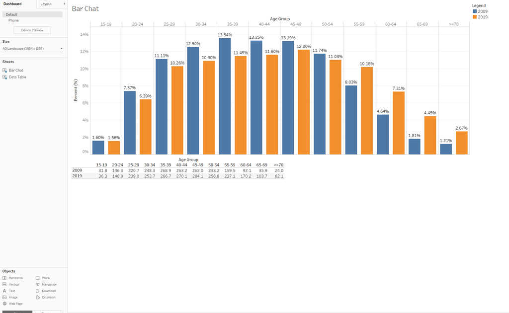

- Adjust the hide and width of the bar chart and data table so that the age groups of the table is aligned to the x-axis of the bar chart. Here, there is a need to fix the size of the dashboard as setting the size to Automatic will mess up the intended alignment between the bar chart and the data table.
- Double-click on the title of the bar chart to amend the title, and include message that the author wants to convey

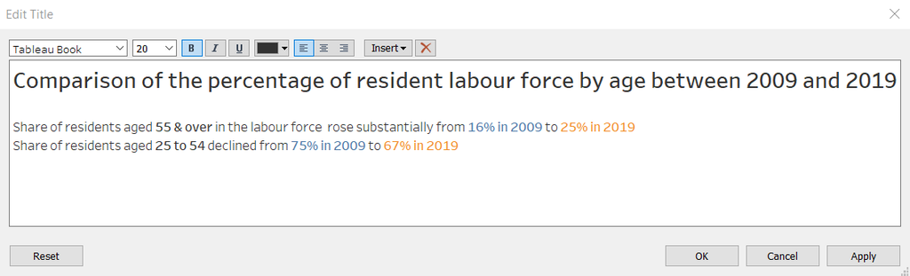

- Finally, include the necessary text and source by draging the Text object into the dashboard

The final dashboard is as shown below, and could be access via the link provided.

[figure not shown]

https://public.tableau.com/profile/dylan7338#!/vizhome/DatavizMakeover1_16118012680840/Dashboard1

# E. Observations revealed by the Data Visualisation prepared